# Replication Code: Benoit et al.(2019) Measureing and Explaining Political Sophistication through Textual Complexity

Author

Zhiqiang Ji

## 1. Introduction

This Quarto notebook is the replication code for Benoit et al.(2019). This study used crowdsourcing to perform thousands of pairwise comparisons of text snippets excerpted from the State of the Union addresses and incorporate these results into a statistical model of sophistication. The official publication can be found online at AJPS, [DOI: 10.1111/ajps.12423](https://doi.org/10.1111/ajps.12423). The authors have generously provided all materials necessary for replicating the analyses presented in their article. These materials are hosted on the *American Journal of Political Science* Dataverse within the Harvard Dataverse Network at: [DOI: 10.7910/DVN/9SF3TI](https://doi.org/10.7910/DVN/9SF3TI).

This replication cannot repeat the crowdsourced coding of the original text data, hence omitting the data collection process. The related code files related to the data preparation for crowdsourcing jobs include: `01a_generate_CF_input_921916.R`, `01b_generate_CF_input_952737.R`, `01c_generate_CF_input_999866.R`, and `02_execute_CF_runs_and_download_data`, which can be found among the Dataverse materials. This replication code will start with the data downloaded from the Dataverse, then proceed to model development and results presentation.

### Structure of the Replication

The original study’s workflow of developing a new model of textual sophistication involves the following steps:

1. Get human judgments of relative textual easiness for political texts.
2. Fit an unstructured Bradley-Terry model for pairwise comparisons to the judgment data from Step 1 and estimate a measure of latent “easiness” for each text.
3. Using the random forest algorithm, estimate the best predictors of the textual easiness from Step 2 among a set of potential determinants of textual sophistication.
4. Using the most highly predictive covariates from Step 3, fit a structured Bradley-Terry model to the judgment data from Step 1 and estimate a measure of latent sophistication for each text, then compare with other measurements.
5. Use the fitted model from Step 4 to “predict” the easiness parameter for a given new text, including:
   - Using the comparative formulation to estimate the relative probability that one new text is easier than another text, or a baseline text;
   - Using nonparametric bootstrapping of the new texts to represent uncertainty in the predicted point estimates.

The following sections will replicate these steps in order. Section 2 will replicate Steps 2-4, and Section 3 will replicate Step 5.

## 2. Fitting a Newe Model of Textual Sophistication

### 2.1 Set up the environment

### 2.2 Generate sentence covariates

The first step in the replication is to generate the covariates for the sentences. The original study used the `spacyr` package to generate covariates for the sentences. The following code will replicate the covariate generation process for the last two jobs in the original study. The covariates include readability measures, baseline covariates, and part-of-speech (POS) covariates. The covariates are then saved in two files. One is a normal data frame while the other is in the ‘chameleons’ format for later use with the `BradleyTerry2` R package.

```r
# Read in the comparison data
getwd()
```

```
[1] "C:/Users/j_i/OneDrive/EDX/GU_2024_Spring/6801/replication/repo"
```

```r
allsentences <-
    rbind(read.csv("data/CF_output_f999866.csv", stringsAsFactors = FALSE),
          read.csv("data/CF_output_f952737.csv", stringsAsFactors = FALSE))
# 27807 obs. of  25 variables

# create chameleons format data
job999866covars_chameleons <-
    bt_input_make(allsentences, covars = TRUE,
                  readability_measure = c("Flesch",
                                          "Dale.Chall",
                                          "FOG",
                                          "SMOG",
                                          "Spache",
                                          "Coleman.Liau"),
                  covars_baseline = TRUE, covars_pos = TRUE, normalize = TRUE)

#save(job999866covars_chameleons, file = "data/my_job999866covars_chameleons.rda")


## Save the same data, as a data.frame

# select just the text and their IDs
allsentences <- allsentences[, c("snippetid1", "text1", "snippetid2", "text2")]
# wrap the sentences
allsentences <- data.frame(snippetid = c(allsentences[, "snippetid1"],
                                         allsentences[, "snippetid2"]),
                           text = c(allsentences[, "text1"],
                                    allsentences[, "text2"]),
                           stringsAsFactors = FALSE)
# just keep the unique ones
allsentences <- allsentences[!duplicated(allsentences$snippetid), ]
nrow(allsentences) # 3322 rows
```

```
[1] 3322
```

```r
# create the basic covariates
allsentences_covars <- cbind(
    allsentences,
    covars_make(allsentences$text, readability_measure = "Flesch"),
    covars_make_baselines(allsentences$text)
)

txt <- allsentences$text
names(txt) <- allsentences$snippetid

# add the POS covariates
allsentences_pos <- covars_make_pos(txt)

job999866covars <-
    merge(allsentences_covars, allsentences_pos, by.x = "snippetid", by.y = "doc_id")
#save(job999866covars, file = "data/my_job999866covars.rda")

## Check the covariates
print(names(job999866covars))
```

```
 [1] "snippetid"             "text"                  "meanSentenceLength"
 [4] "meanWordSyllables"     "Flesch"                "W"
 [7] "St"                    "C"                     "Sy"
[10] "W3Sy"                  "W2Sy"                  "W_1Sy"
[13] "W6C"                   "W7C"                   "Wlt3Sy"
[16] "W_wl.Dale.Chall"       "meanWordChars"         "meanSentenceChars"
[19] "meanSentenceSyllables" "brown_mean"            "brown_min"
[22] "google_mean_2000"      "google_min_2000"       "n_namedentities"
[25] "n_sentence"            "n_noun"                "n_verb"
[28] "n_adjective"           "n_adverb"              "n_clause"
[31] "ntoken"                "pr_sentence"           "pr_noun"
[34] "pr_verb"               "pr_adjective"          "pr_adverb"
[37] "pr_clause"
```

**Note**: Please refer to the codebook.pdf file under the `data` folder for the description of the covariates.

### 2.3 Make unstructured brTandF abilities

The next step is to fit an unstructured Bradley-Terry model to the judgment data. The following code will fit the unstructured model with and without bias reduction. The model will be used to predict the easiness for a given new text.

The authors of the original study fitted the model with and without bias reduction. The model with bias reduction is used to predict the easiness of the new texts. The model without bias reduction is used to predict the easiness of the new texts and compare the results with the model with bias reduction. The choice between these two choices turned out to be unimportant for the selection of important predictors in the next step.

**Note**: Fitting the unstructured B-T models takes about 4-6 hours depending on machine speed.

```r
load("data/my_job999866covars_chameleons.rda")
dat <- job999866covars_chameleons
## Check the data
summary(dat)
```

```
           Length Class      Mode
easier      1     data.frame list
harder      1     data.frame list
predictors 43     data.frame list
```

```r
# str(dat) ## 2469 docs, 19430 comparisons


## Fit the unstructured B-T models
## With bias reduction

# fit unstructured model (br=T)
# BT_unstruc_brT <-
#     BTm(player1 = easier, player2 = harder, br = TRUE, id = "ID", data = dat)
# save(BT_unstruc_brT, file = "data/my_BT_unstructured_brT_abilities.rda")


## No bias reduction

# fit unstructured model (br=F)
# BT_unstruc_brF <-
#     BTm(player1 = easier, player2 = harder, br = FALSE, id = "ID", data = dat)
# save(BT_unstruc_brF, file ="data/my_BT_unstructured_brF_abilities.rda")
```

### 2.4 RandomForest variable selection

This step will use both B-T models with or without bias reduction to fit RF selection of the most important predictors.

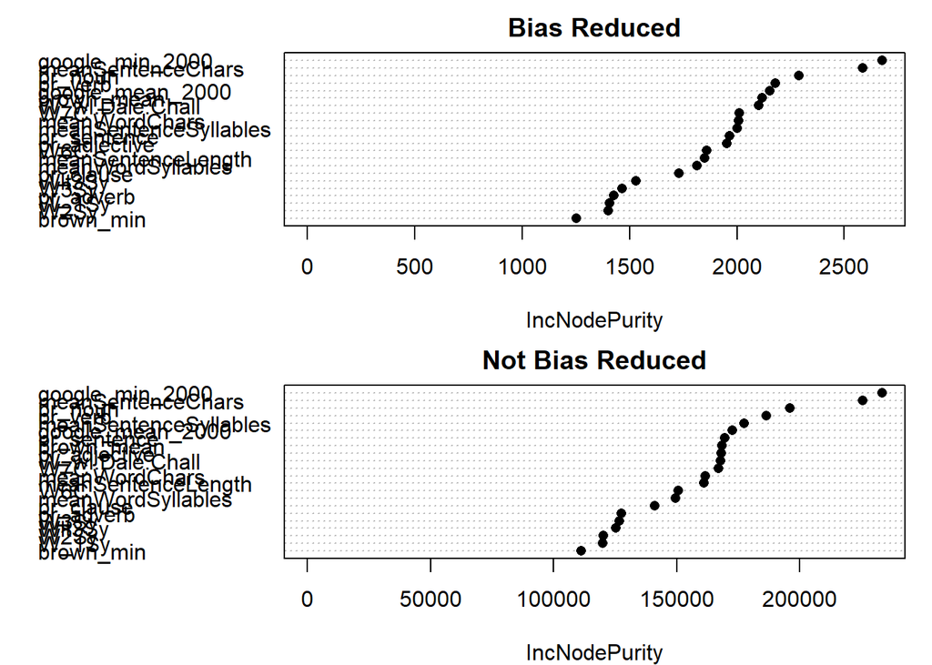

```r
## Fit the Random Forest using the B-T model WITH bias reduction
set.seed(42)
load("data/my_BT_unstructured_brT_abilities.rda")
BT1 <- BT_unstruc_brT

# locate the relevant predictors in the predictors part of the data
y <- BTabilities(BT1)[, "ability"]
yy <- y[!is.na(y)] #remove NAs
m <- match(names(yy), rownames(dat$predictors))

# collect the possible terms -- note that we remove Flesch (because it's aliased by the other variables)
terms <- c("W3Sy", "W2Sy", "W_1Sy", "W6C", "W7C", "W_wl.Dale.Chall", "Wlt3Sy",
           "meanSentenceLength", "meanWordSyllables", "meanWordChars",
           "meanSentenceChars", "meanSentenceSyllables", "brown_mean", "brown_min",
           "google_mean_2000", "google_min_2000", "pr_noun", "pr_verb", "pr_adjective",
           "pr_adverb", "pr_clause", "pr_sentence")


X <- dat$predictors[m, terms]

# fit the RF model
mod <- randomForest(X, y = yy, ntree = 1000)
mod_bias_reduced<-mod
# save(x = mod_bias_reduced, file = "data/my_rf_model_bias_reduced.rda")


## Fit RF with NO bias reduction
set.seed(42)
load("data/my_BT_unstructured_brF_abilities.rda")
BT2 <-  BT_unstruc_brF

# locate the relevant predictors in the predictors part of the data
y2 <- BTabilities(BT2)[, "ability"]
yy2 <- y2[!is.na(y2)] #remove NAs
mm <- match(names(yy2), rownames(dat$predictors))

X2 <- dat$predictors[mm, terms]

# use randomForest instead of VSURF
mod2 <- randomForest(X2, y = yy2, ntree = 1000)
mod_non_bias_reduced<-mod2
# save(x = mod_non_bias_reduced, file = "data/my_rf_model_non_bias_reduced.rda")

# Plot the predictors' importance
# prevent the variable names from overlapping
par(mfrow=c(2,1), mar=c(4,4,2,1))
varImpPlot(mod_bias_reduced, main = "Bias Reduced", pch = 16)
varImpPlot(mod_non_bias_reduced, main = "Not Bias Reduced", pch = 16)
```

```r
dev.copy2pdf(file = "figures/figureS1.pdf",
             width = 11, height = 9)
```

```r
dev.off()
```

The results of the RF predictor selections are shown in Figure S1. Both unstructured B-T models with and without bias reduction show that the most important predictors are the same. The replication of this step confirms the significance of two new kinds of measures the authors introduced to the measurements of sophistication: `google_min_2000` for word rarity, and `pr_noun` for content complexity.

### 2.5 Additional covariates for the requested texts

This step gets the covariate information for the average covariate values of paragraphs that span the entirety of each SOTU address under study.

```r
## Make additional covariates for the requested texts

# SOTU addresses
data(data_corpus_sotu, package = "quanteda.corpora")

# x1 <- covars_make(data_corpus_sotu)
# x2 <- covars_make_pos(data_corpus_sotu)
# x3 <- covars_make_baselines(data_corpus_sotu,
#                             baseline_year = lubridate::year(docvars(data_corpus_sotu, "Date")))
#
# sotu_covars <- cbind(x1, x2, x3)
# save(sotu_covars, file = "data/my_sotu_covars.rda")
```

### 2.6 Fit the “Best Models” and Evaluate Results

Now, we will fit four models: the “basic Flesch”, the “optimal Flesch”, the “basic RF” and the “best” structured B-T models. The latter two are using the top covariates selected in the RF step. The “basic RF” model is the one that includes the covariates `google_min_2000`, `meanSentenceChars`, and `pr_noun`; and the “Best” includes an additional `meanWordChars`. We will also evaluate the results of the model.

**Note**: Each of these models takes about 60 seconds to fit. Thus, bootstrapping the proportion of contests correctly predicted (PCP) is very expensive. This replication took about 30 hours to finish the bootstrapping process.

```r
## Fit structured BT models ============
# # baseline Flesch model
# BT_basic_Flesch <- BTm(player1 = easier, player2 = harder,
#                        formula = ~ Flesch[ID], id = "ID",
#                        data = job999866covars_chameleons)
#
# # optimal Flesch model
# BT_optimal_Flesch <- BTm(player1 = easier, player2 = harder,
#                          formula = ~ meanSentenceLength[ID] + meanWordSyllables[ID],
#                          id = "ID", data = job999866covars_chameleons)
#
# # basic RF model
# BT_basic_RF <- BTm(player1 = easier, player2 = harder,
#                    formula = ~ google_min_2000[ID] + meanSentenceChars[ID] + pr_noun[ID],
#                    id ="ID", data = job999866covars_chameleons)
#
# # best model
# BT_best <- BTm(player1 = easier, player2 = harder,
#                formula = ~ google_min_2000[ID] +  meanSentenceChars[ID] + pr_noun[ID] + meanWordChars[ID],
#                id = "ID", data = job999866covars_chameleons)
#
# # save the results
# model_results <- list(BT_basic_Flesch = BT_basic_Flesch,
#                       BT_basic_RF = BT_basic_RF,
#                       BT_optimal_Flesch = BT_optimal_Flesch,
#                       BT_best = BT_best)

#save(model_results, file = "data/my_Best_Model_Results_list.rda")
load("data/my_Best_Model_Results_list.rda")
model_results <- model_results

#save(BT_best, file = "data/my_BT_best.rda")
load("data/my_BT_best.rda")
BT_best <- BT_best

## OUTPUT FOR TABLE 2 ================

# function for fit (percent corr predicted)
prop.correct <- function(x = BTFRE) {
    sum(predict(x, type = "response") > .5) / length(predict(x, type = "response"))
}

# with(model_results, apsrtable(BT_basic_Flesch, BT_optimal_Flesch, BT_basic_RF, BT_best))

# order the models in descending order of PCP
# model_results <- model_results[names(sort(sapply(model_results, prop.correct), decreasing = TRUE))]

# output models in terms of PCP
table2 <- paste("\nBottom row of TABLE 2\n -----------------------------------------\n",
                sprintf("%-20s ", "Model"), "     PCP      AIC\n",
                "========================  =====  ========\n")
for (m in seq_along(model_results)) {
    table2 <- paste(table2,
                    sprintf("%-25s", names(model_results)[m]),
                    sprintf("%2.3f", prop.correct(model_results[[m]]) / .79),  # <- .79 is the upperbound of the PCP
                    sprintf(" %5.2f", model_results[[m]][["aic"]]),
                    "\n")
}
table2 <- paste0(table2, " -----------------------------------------\n\n")
cat(table2)
```

```
Bottom row of TABLE 2
 -----------------------------------------
 Model                      PCP      AIC
 ========================  =====  ========
 BT_basic_Flesch           0.718  26274.35
 BT_basic_RF               0.735  25921.56
 BT_optimal_Flesch         0.736  25923.47
 BT_best                   0.741  25748.68
 -----------------------------------------
```

```r
## Original code note:
# Bottom row of TABLE 2
# Model                      PCP      AIC
# BT_basic_Flesch           0.719  26267.79
# BT_basic_RF               0.737  25915.01
# BT_optimal_Flesch         0.738  25910.29
# BT_best                   0.741  25740.25
```

The replicated results are slightly different from the original study’s evaluation of PCP and AIC. The differences are likely due to the random seed used in the replication. The replication results are consistent with the original study’s findings, showing that the “best” model has the highest PCP and the lowest AIC.

**Note 1: Upper bound of PCP**

It should be noted that the PCP is adjusted by dividing by 0.79, which is the upper bound of the PCP. This adjustment is necessary because the PCP is not a true probability, but a measure of the proportion of contests correctly predicted. Due to the nature of the crowdsourced coding job, the judgment may have discrepancies for the same pair of snippets if they are judged multiple times, hence there is a upper bound for model performance. For example, if one pair of snippets have been judged by 3 coders and only two of them had the same judgment, the best PCP a model can get is 2/3.

More detailed discussion about the upper bound of PCP can be found in the original study’s Supporting Information, Section D “Assessing model performance”. Also, the code to produce this upper bound of 0.79 can be found in the original study’s code file `11_supplemental_analysis.R`. This replication will not repeat the code here.

**Note 2: Possible typo in the paper**

The order of the models in the original paper’s Table 2 (p.501) is different from the order of the models in the code. In the paper the “basic_RF” model has a PCP of 0.738 while the “optimal_Flesch” model has a PCP of 0.737. However, in the code, according to the original code note as well as the replication results, the “optimal_Flesch” model has a slightly higher PCP than the “basic_RF” one by 0.001. The AIC values in the original code note are consistent with the paper.

```r
## Bootstrap Confidence Intervals for PCP

# we want to bootstrap the results of a BT model
# to do that, we can use the internal subset= argument
# Except that, in each case, the subset is a sample of all the rows

# function for fit (percent corr predicted)
prop.correct <- function(x = BTFRE) {
    sum(predict(x, type = "response") > .5) / length(predict(x, type = "response"))
}

# Basic function to do a subset bootstrap
# It returns an accuracy estimate adjusted as it should be
boot.one.time <- function(d = job999866covars_chameleons, refmodel) {
    samp <<- sample(1:nrow(d$easier), nrow(d$easier), replace = TRUE)
    model.call <<- as.formula(refmodel)
    BT_resamp <<- BTm(player1 = easier, player2 = harder, formula = model.call,
                      id = "ID", data = job999866covars_chameleons, subset = samp)
    adj.acc <<- prop.correct(BT_resamp) / 0.79
    adj.acc
}

attach(model_results)
n <- 500 # number of samples

# baseline Flesch model bootstrap
# # so let's fit this to the BT_basic_Flesch model, 2 times
# bs.draws_basic <- replicate(n, boot.one.time(d=job999866covars_chameleons, refmodel = BT_basic_Flesch))
#
# # basic RF model
# bs.draws_basicRF <- replicate(n, boot.one.time(d=job999866covars_chameleons, refmodel = BT_basic_RF))
#
# # optimal Flesch model
# bs.draws_opt <- replicate(n, boot.one.time(d=job999866covars_chameleons, refmodel = BT_optimal_Flesch))
#
# # best model
# bs.draws_best <- replicate(n, boot.one.time(d=job999866covars_chameleons, refmodel = BT_best))
#
# BS_results <- data.frame(bs.draws_basic, bs.draws_basicRF, bs.draws_opt, bs.draws_best)
# detach(model_results)
# save(BS_results, file = "data/bootstrap_results_AJPSR2.rda")
load("data/bootstrap_results_AJPSR2.rda")
BS_results <- BS_results
```

### 2.7 Compare the Performance

```r
## Replicate Table 2 to compare the performance of the models

# Create a empty dataframe to store the results
coefficients_table <- data.frame()

# Extract the coefficients from each model
for(m in names(model_results)) {
  model_coef_summary <- summary(model_results[[m]])$coefficients
  aic_score <- model_results[[m]][["aic"]]
  model_df <- data.frame(
    Coefficient = rownames(model_coef_summary),
    Estimate = model_coef_summary[, "Estimate"],
    StdError = model_coef_summary[, "Std. Error"],
    Model = m
  )
  coefficients_table <- rbind(coefficients_table, model_df)
}

coefficients_table <- coefficients_table %>%
  mutate(Estimate_and_StdError = paste0(round(Estimate, 3), " (", round(StdError, 3), ")")) %>%
  select(-Estimate, -StdError)

coefficients_table_wide <- coefficients_table %>%
  spread(key = Model, value = Estimate_and_StdError)

## Add AIC scores to the table
aic_scores <- sapply(model_results, function(m)round( m[["aic"]],2))
aic_df_wide <- data.frame(Coefficient = "AIC", t(data.frame(aic_scores)))
row.names(aic_df_wide) <- NULL
coefficients_table_wide  <- rbind(coefficients_table_wide , aic_df_wide)

## Add PCP to the table
PCP_scores <- sapply(BS_results, function(y) round(mean(y), 3))
PCP_df_wide <- data.frame(Coefficient = "PCP", t(data.frame(PCP_scores)))
row.names(PCP_df_wide) <- NULL
# Change column names
colnames(PCP_df_wide) <- c("Coefficient", "BT_basic_Flesch", "BT_basic_RF", "BT_optimal_Flesch", "BT_best")
coefficients_table_wide  <- rbind(coefficients_table_wide , PCP_df_wide)


## Add the CI to the table
CI <- sapply(BS_results, function(y) round(quantile(y, c(0.025, .975)), 3))
CI_df <- as.data.frame(CI)
CI_row <- apply(CI_df, 2, function(x) paste0("[", x[1], ", ", x[2], "]"))
CI_df_row <- data.frame(Coefficient = "[95% CI]", t(CI_row))
colnames(CI_df_row) <- c("Coefficient", "BT_basic_Flesch", "BT_basic_RF", "BT_optimal_Flesch", "BT_best")
coefficients_table_wide <- rbind(coefficients_table_wide, CI_df_row)

ordered_columns <- c("Coefficient", "BT_basic_Flesch", "BT_optimal_Flesch", "BT_basic_RF", "BT_best")
coefficients_table_ordered <- coefficients_table_wide %>%
  select(all_of(ordered_columns))

stargazer(coefficients_table_ordered, type = "html",
          title = "Coefficients and Performance of the Four Structured Models",
          summary = FALSE)
```

**Coefficients and Performance of the Four Structured Models**

|  | Coefficient | BT_basic_Flesch | BT_optimal_Flesch | BT_basic_RF | BT_best |
| --- | --- | --- | --- | --- | --- |
| 1 | Flesch[ID] | 0.02 (0.001) |  |  |  |
| 2 | google_min_2000[ID] |  |  | 1318.889 (153.389) | 1336.446 (155.916) |
| 3 | meanSentenceChars[ID] |  |  | -0.015 (0.001) | -0.014 (0.001) |
| 4 | meanSentenceLength[ID] |  | -0.062 (0.003) |  |  |
| 5 | meanWordChars[ID] |  |  |  | -0.311 (0.024) |
| 6 | meanWordSyllables[ID] |  | -1.773 (0.07) |  |  |
| 7 | pr_noun[ID] |  |  | 0.489 (0.167) | 0.348 (0.168) |
| 8 | AIC | 26274.35 | 25923.47 | 25921.56 | 25748.68 |
| 9 | PCP | 0.718 | 0.737 | 0.736 | 0.742 |
| 10 | [95% CI] | [0.709, 0.727] | [0.727, 0.745] | [0.727, 0.746] | [0.733, 0.752] |

The replication of the “Table 2” of the paper confirms the original results, despite the trivial differences in numbers. The coefficients of the four models are consistent with the original results. The performance of the four models is also consistent with the original results. The 95% confidence intervals of the PCP scores are consistent with the original results.

## 3. Apply the Models to the Texts

### 3.1 Compare snippets (Generate Table_3)

For this section, I retained the original in-code notes on the results to facilitate comparison with the outcomes of my models.

```r
# I added two pieces of texts from the speeches of Obama and Trump

txt_clinton <- "If we do these things-end social promotion; turn around failing schools; build modern ones; support qualified teachers; promote innovation, competition and discipline-then we will begin to meet our generation's historic responsibility to create 21st century schools.  Now, we also have to do more to support the millions of parents who give their all every day at home and at work."

txt_bush <- "And the victory of freedom in Iraq will strengthen a new ally in the war on  terror, inspire democratic reformers from Damascus to Tehran, bring more hope  and progress to a troubled region, and thereby lift a terrible threat from the  lives of our children and grandchildren.  We will succeed because the Iraqi  people value their own liberty---as they showed the world last Sunday."

txt_obama <- "Some schools redesign courses to help students finish more quickly.  Some use better technology.  The point is, it’s possible.  So let me put colleges and universities on notice:  If you can’t stop tuition from going up, the funding you get from taxpayers will go down.Higher education can’t be a luxury -– it is an economic imperative that every family in America should be able to afford."

txt_trump <- "This is a moral issue.  The lawless state of our southern border is a threat to the safety, security, and financial wellbeing of all America.  We have a moral duty to create an immigration system that protects the lives and jobs of our citizens.  This includes our obligation to the millions of immigrants living here today who followed the rules and respected our laws."

corp_example <- corpus(c(Clinton_1999 = txt_clinton, Bush_2005 = txt_bush, Obama_2012 = txt_obama, Trump_2019 = txt_trump))

example_covs <- covars_make_all(corp_example)


# TABLE 3 OUTPUT ---------
# Check the key covariates for each snippet
tab2 <- as.data.frame(sophistication:::get_covars_from_newdata.corpus(corp_example))
row.names(tab2) <- tab2[, "_docid"]
tab2 <- tab2[, c("google_min", "meanSentenceChars", "pr_noun", "meanWordChars")]
tab2 <- t(tab2)
tab2[1, , drop = FALSE]
```

```
           Clinton_1999    Bush_2005   Obama_2012   Trump_2019
google_min 0.0002651632 1.399289e-08 2.758526e-06 2.758526e-06
```

```r
round(tab2[2:4, ], 2)
```

```
                  Clinton_1999 Bush_2005 Obama_2012 Trump_2019
meanSentenceChars       155.50    153.50      62.20      74.50
pr_noun                   0.29      0.23       0.22       0.30
meanWordChars             4.94      4.72       4.51       4.66
```

```r
#                   Clinton_1999 Bush_2005
# meanSentenceChars       155.50    153.50
# pr_noun                   0.30      0.23
# meanWordChars             4.94      4.72
```

```r
# ---- lambdas computed with precision
load("data/my_BT_best.rda")
(prd <- predict_readability(BT_best, corp_example))
```

```
                lambda      prob    scaled
Clinton_1999 -3.213821 0.2616357  38.57879
Bush_2005    -3.493522 0.2112869  22.01989
Obama_2012   -2.175249 0.5002719 100.06439
Trump_2019   -2.362582 0.4535730  88.97393
```

```r
prd
```

```
                lambda      prob    scaled
Clinton_1999 -3.213821 0.2616357  38.57879
Bush_2005    -3.493522 0.2112869  22.01989
Obama_2012   -2.175249 0.5002719 100.06439
Trump_2019   -2.362582 0.4535730  88.97393
```

```r
#                 lambda      prob   scaled
# Clinton_1999 -3.250914 0.2545336 36.38281
# Bush_2005    -3.528247 0.2055582 19.96412

# verify lambdas
coef(BT_best) %*% tab2
```

```
     Clinton_1999 Bush_2005 Obama_2012 Trump_2019
[1,]    -3.213821 -3.493522  -2.175249  -2.362582
```

```r
# ---- REPORTED LAMBDAS FROM TABLE 3
tab2rounded <- round(tab2, 2)
tab2rounded[1, 1] <- round(tab2[1, 1], 6)
tab2rounded[1, 2] <- round(tab2[1, 2], 10)
tab2lambdas <- round(round(coef(BT_best), 2) %*% tab2rounded, 2)
tab2lambdas
```

```
     Clinton_1999 Bush_2005 Obama_2012 Trump_2019
[1,]        -2.63     -2.92      -1.94      -2.08
```

```r
#      Clinton_1999 Bush_2005
# [1,]        -2.64     -2.93
```

The replication results fit the results of the `Table 3` of the original paper.

```r
# ---- Pr(Clinton snippet easier than Bush snippet) from TEXT
exp(tab2lambdas[1, "Clinton_1999"]) /
    (exp(tab2lambdas[1, "Clinton_1999"]) + exp(tab2lambdas[1, "Bush_2005"]))
```

```
Clinton_1999
   0.5719961
```

```r
exp(tab2lambdas[1, "Obama_2012"]) /
    (exp(tab2lambdas[1, "Obama_2012"]) + exp(tab2lambdas[1, "Trump_2019"]))
```

```
Obama_2012
 0.5349429
```

```r
# Clinton_1999
#    0.5719961
```

```r
## lambdas v. fifth-grade texts in text of 5.2
lamba5thgrade <-
    predict_readability(BT_best, newdata = corpus_group(data_corpus_fifthgrade, groups = rep(1, ndoc(data_corpus_fifthgrade))))[, "lambda"]
lamba5thgrade
```

```
[1] -2.196466
```

```r
# redo with correct reference
predict_readability(BT_best, reference_top = lamba5thgrade,
                    newdata = corpus_group(data_corpus_fifthgrade, groups = rep(1, ndoc(data_corpus_fifthgrade))))
```

```
     lambda prob scaled
1 -2.196466  0.5    100
```

```r
#      lambda prob scaled
# 1 -2.193864  0.5    100

# clinton and bush
predict_readability(BT_best, reference_top = lamba5thgrade, newdata = corp_example)
```

```
                lambda      prob    scaled
Clinton_1999 -3.213821 0.2655429  39.04407
Bush_2005    -3.493522 0.2146608  22.28546
Obama_2012   -2.175249 0.5053040 101.27123
Trump_2019   -2.362582 0.4585663  90.04701
```

```r
#                 lambda      prob   scaled
# Clinton_1999 -3.250914 0.2578736 36.76429
# Bush_2005    -3.528247 0.2084353 20.17345
```

It is surprising to see how the scaled score of Obama_2012 snippet (a paragraph on education) is slightly easier to read than the fifth grade level, which resonates well with the author’s account on the limit of this sophistication measure that “great academic writers might be able to describe extremely complicated ideas in straightforward ways for popular audiences.”

### 3.2 Reanalyzing the State of the Union Addresses

The authors have provide very detailed implementation of the following examples. I did not have much room to change the code.

**Note**: Annotating the SOTU paragraphs here can take between 30-40 minutes.

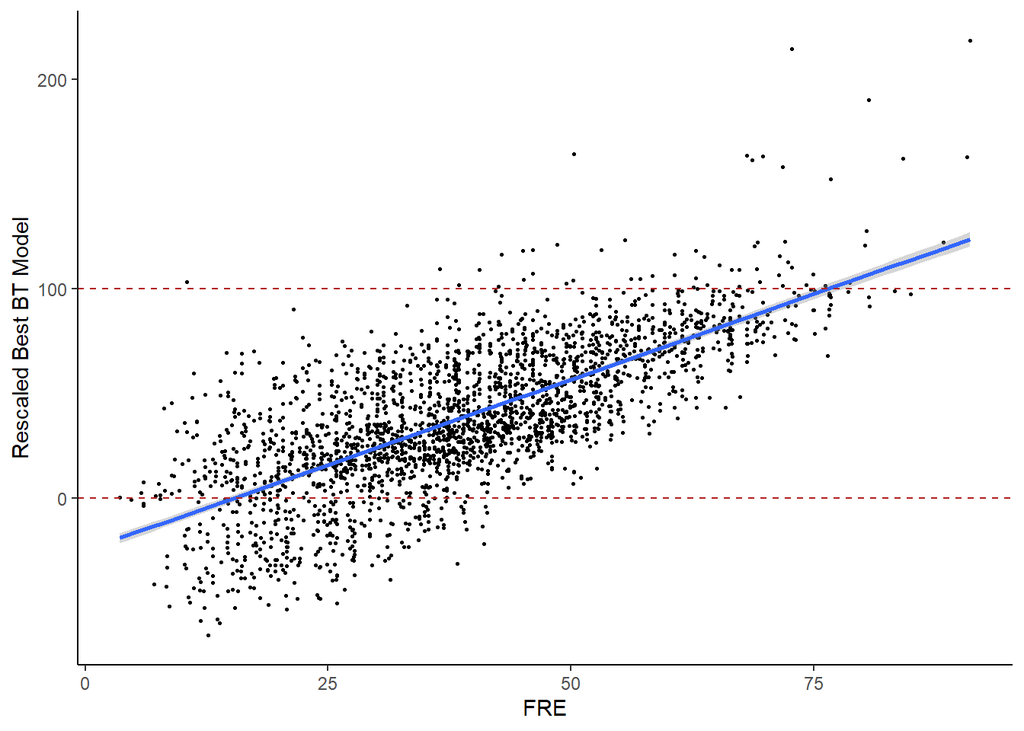

```r
# # convert to paragraphs and tidy up
# data_corpus_sotuparagraphs <- corpus_reshape(data_corpus_sotu, to = "paragraphs")
# toremove <- rep(FALSE, ndoc(data_corpus_sotuparagraphs))
#
# # remove paragraphs with all caps titles
# toremove <- toremove |
#     grepl("^([A-Z0-9[:punct:]]+\\s{0,1})+\\.{0,1}$", corpus_group(data_corpus_sotuparagraphs))
# # remove paragraphs with long figures (from a table)
# toremove <- toremove |
#      grepl("(\\d{1,3}(,\\d{3}){1,}(\\.\\d{2})*(\\s\\-\\s)+)", corpus_group(data_corpus_sotuparagraphs))
# # remove any snippets with long ....
# toremove <- toremove |
#     grepl("\\.{4,}", corpus_group(data_corpus_sotuparagraphs))
#
# # remove any snippets with ----- (indicates a table)
# toremove <- toremove |
#      grepl("\\-{4,}", corpus_group(data_corpus_sotuparagraphs))
#
# # remove e.g. "(a) For veterans."
# toremove <- toremove |
#     (grepl("^\\([a-zA-Z0-9]+\\)\\s+.*\\.$",  corpus_group(data_corpus_sotuparagraphs)) &
#          ntoken(data_corpus_sotuparagraphs) <= 30)
# data_corpus_sotuparagraphs <- corpus_subset(data_corpus_sotuparagraphs, !toremove)
#
#
# # summary statistics
# # summary(summary(data_corpus_sotuparagraphs, n = ndoc(data_corpus_sotuparagraphs)))
#
# # add readability stats
# docvars(data_corpus_sotuparagraphs, "Flesch") <-
#    textstat_readability(data_corpus_sotuparagraphs, "Flesch")[["Flesch"]]
#
# set.seed(42)
#
# # add predicted BMS "static"
# rdblty_2000 <- predict_readability(BT_best, data_corpus_sotuparagraphs,
#                                   baseline_year = 2000, bootstrap_n = 100)
# names(rdblty_2000) <- paste(names(rdblty_2000), "2000", sep = "_")
# # add predicted BMS "dynamic"
# rdblty_local <- predict_readability(BT_best, data_corpus_sotuparagraphs,
#                                     baseline_year = lubridate::year(docvars(data_corpus_sotuparagraphs, "Date")),
#                                     bootstrap_n = 100)
# names(rdblty_local) <- paste(names(rdblty_local), "local", sep = "_")
#
# docvars(data_corpus_sotuparagraphs) <-
#     cbind(docvars(data_corpus_sotuparagraphs), rdblty_2000, rdblty_local)
#
# save(data_corpus_sotuparagraphs, file = "data/my_data_corpus_sotuparagraphs.rda")

## Generate Figures 1-3

# create a subfolder for figures
#dir.create("figures", showWarnings = FALSE)

## FIGURE 1 --------

# get FRE scores for the snippets
FRE <- dat$predictors$Flesch
names(FRE) <- rownames(dat$predictors)

load("data/my_BT_best.rda")
# get lambdas from BMS best fitting model
main_lambdas <- BTabilities(BT_best)[,"ability"]

# rescale lambdas to the 0-100 space correctly
rescaled_lambdas <- 226.06927 + 57.93899 * main_lambdas
# check that they are matched up
m <- match(names(FRE), names(rescaled_lambdas)) ## they are matched up

ggplot(data.frame(FRE = FRE, rslambda = rescaled_lambdas), aes(x = FRE, y = rslambda)) +
    geom_point(size = .6) +
    labs(y = "Rescaled Best BT Model") +
    geom_smooth(method = "lm", se = TRUE) +
    geom_hline(yintercept = c(0, 100), linetype = "dashed", color = "firebrick") +
    theme(axis.text.x = element_text(size = 5),
          axis.text.y = element_text(size = 5)) +
    theme_classic()
```